# gis-ws-08-1

santowsa, CoWeber, aschupp

16 Januar 2018

# Horizontal Diversity

```r
mainDir <- "E:/gIs/horizont/"
inDir <- "input/"
outDir<- "output/"
results<-"hor_class/"
Fusion<-"E:/gIs/FUSION/"
library(sp)
library(raster)
library(rgdal)
rasterOptions(maxmemory=1e+08)
source(paste0(mainDir,"function_horizon.R"))

################################################################################

lasfiles<-list.files(paste0(mainDir,inDir),pattern=".las$", full.names=FALSE)
#einfügen #height und #cellsize und #col
#bei uns dann height=0, cellsize=1 und col=38 bzw col=6 beio dgm, etc bla bla
statistics(lasList = lasfiles)
DSM(lasList = lasfiles)
DGM(lasList = lasfiles)
CHM(lasList = lasfiles)
GAP(lasList = lasfiles)
SLP(lasList = lasfiles)
```

## Results for horizontal diversity calculation

### 1. Variance of Canopy height model (CHM_var 9x9m) for height diversity

Variance of CHM is used to determine the jump between differen height levels in an area of 9x9m:

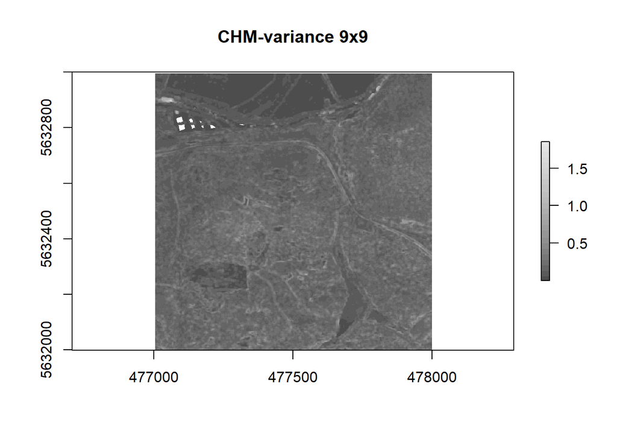

### 2. Results for GAP’s (9x9m) and suddenly clear vertical height diversity

GAP_mean is created for a next step (see explanations) and GAP_var visualizes the jump in height in the 10th percentile from the CHM.

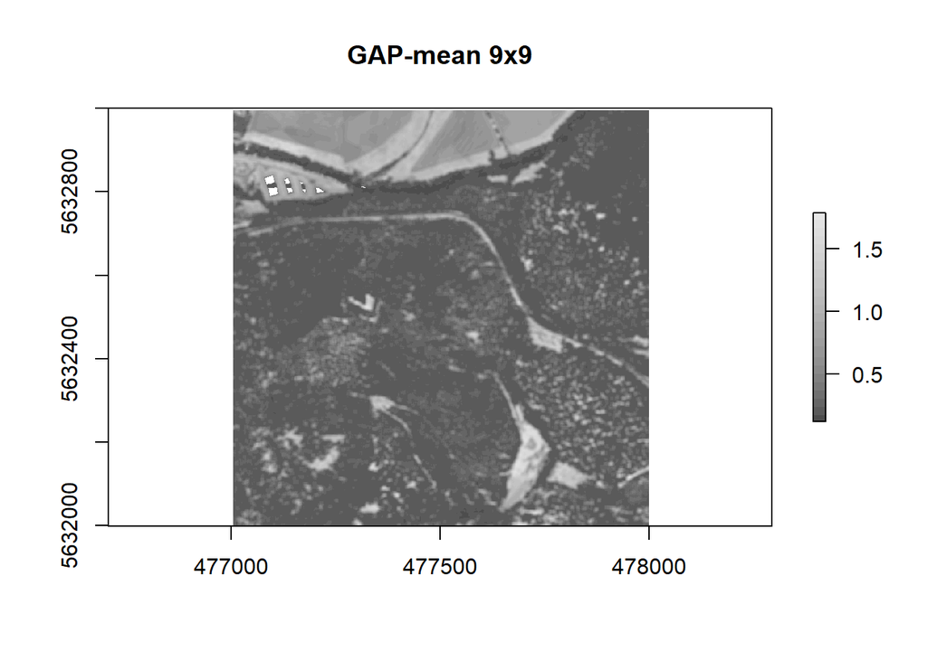

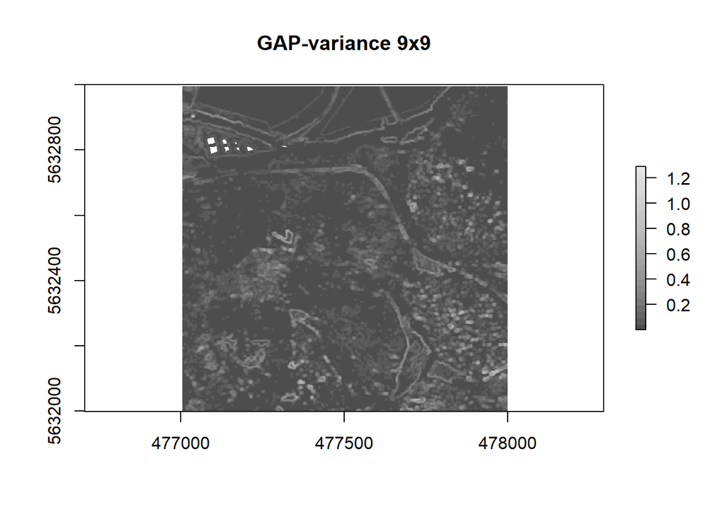

### 3. Results for SLP (slope, 25x25m) of CH

the slope (high values) show like GAP_var an indication for gaps and can be used for more calculations (see Explanations)

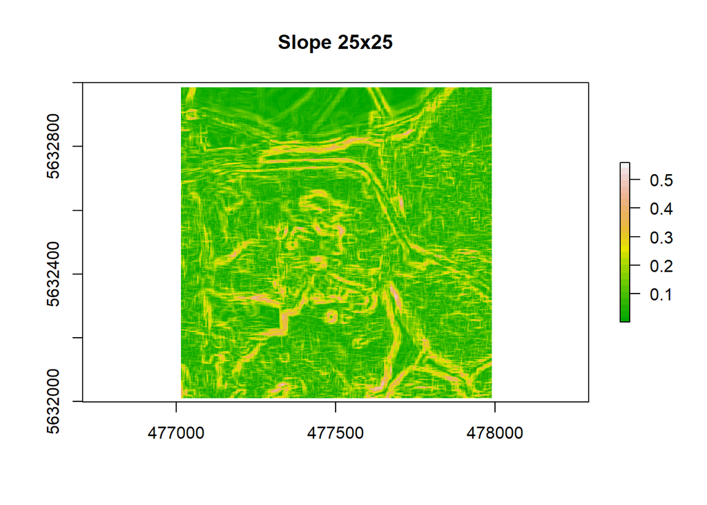

## Explanations

The 10th percentile is choosen because a jump in this percentile could predict the line between cleared areas and “real” forest.

Next step could be to compare the difference between the GAP-rasters and the SLP to predict “real” gaps. If you compare the shaped forms from the SLP-raster with CH_mean areas which show the same height (-> no big CH_var value) you got a gap.

The oter thing we noticed is SLP shows circular objectives in the forest where neither a high var in the 10th percentile is visible nor a gap is possible in any way. Those slope jumps are the transition between beech and spruce stocks.

## Source function code:

```r
missingExtents<-function(catalogTable, Name){

  for (i in 3:nrow(catalogTable)){

    findrows <- which(catalogTable$MinX ==0|catalogTable$MinY==0|
                        catalogTable$MaxX==0|catalogTable$MaxY==0)

    for (j in findrows){
      coor<-substr(catalogTable[j,1],nchar(as.character(catalogTable[j,1]))-10, nchar(as.character(catalogTable[j,1])))

      xmin<-paste0(substr(coor, 1,3), "000")

      ymin<-paste0(substr(coor, 4,7), "000")

      catalogTable[j,]$MinX=as.numeric(xmin)

      catalogTable[j,]$MinY=as.numeric(ymin)
    }}
  write.csv(catalogTable,paste0(mainDir, outDir,Name,".csv"))
}
###########################################################################

statistics<-function(lasList){
  for (i in lasList){
    system(paste0(Fusion, "catalog.exe ",mainDir, inDir, i," ",
                  mainDir, outDir,i, ".html"))
    extent<-read.csv(paste0(mainDir, outDir,i,".csv"))
    if(extent$MinX==0){
      missingExtents(catalogTable=extent, Name=i)
      extent<-read.csv(paste0(mainDir, outDir,i,".csv"))
    }
    system(paste0(paste0(Fusion, "clipdata.exe"," /class:2 ",
                         mainDir, inDir, i," ",
                         mainDir, outDir,i, "_GroundPts.las "),
                  paste(extent$MinX,extent$MinY,extent$MaxX,extent$MaxY))
    )
    system(paste0(Fusion, "gridsurfacecreate.exe ",
                  mainDir, outDir, i,"_GridSurf.dtm ",
                  "1 M M 1 32 0 0 ",mainDir, outDir,i, "_GroundPts.las"))
    system(paste0(Fusion, "gridmetrics.exe ",mainDir,outDir,i,"_GridSurf.dtm ",0," " ,1," " ,mainDir, results,i,
                  "_vdr.csv ", mainDir,inDir,i))
}}

#######################################################################################

DSM<-function(lasList){
  for (i in lasList){
    system(paste0(Fusion, "csv2grid.exe ", mainDir, results,i,"_vdr_all_returns_intensity_stats.csv ",38," ",
                  mainDir, results, i,"_dsm.asc"))
    tempo=raster(paste0(mainDir,results,i, "_dsm.asc"))
    projection(tempo) <- CRS("+init=epsg:25832")
    writeRaster(tempo,paste0(mainDir,results,i, "_DSM."),format="GTiff" )
}}

#######################################################################################

DGM<-function(lasList){
  for (i in lasList){
    system(paste0(Fusion, "csv2grid.exe ", mainDir, results,i,"_vdr_all_returns_intensity_stats.csv ",6," ",
                  mainDir, results, i,"_dgm.asc"))
    tempo=raster(paste0(mainDir,results,i, "_dgm.asc"))
    projection(tempo) <- CRS("+init=epsg:25832")
    writeRaster(tempo,paste0(mainDir,results,i, "_DGM."),format="GTiff" )
}}

#######################################################################################

CHM<-function(lasList){
  for (i in lasList){
    CH=(raster(paste0(mainDir,results,i,"_DSM.tif")))-
      (raster(paste0(mainDir,results,i,"_DGM.tif")))
    writeRaster(CH,paste0(mainDir,results,i,"_CH."),format="GTiff" )

    var_CH=focal(CH,w=matrix(1/81,nrow = 9,ncol = 9),na.rm=T,fun=var)
    writeRaster(var_CH,paste0(mainDir,results,i,"_CH_var."),format="GTiff" )
}}

########################################################################################################

GAP<-function(lasList){
  for (i in lasList){
    system(paste0(Fusion, "csv2grid.exe ", mainDir, results,i,"_vdr_all_returns_intensity_stats.csv ",26," ",
                  mainDir, results, i,"_gap.asc"))
    tempo=raster(paste0(mainDir,results,i, "_gap.asc"))
    projection(tempo) <- CRS("+init=epsg:25832")
    writeRaster(tempo,paste0(mainDir,results,i, "_GAP."),format="GTiff" )
    GaP=(raster(paste0(mainDir,results,i,"_GAP.tif")))
    mean_GaP=focal(GaP,w=matrix(1/81,nrow = 9,ncol = 9),na.rm=T,fun=mean)
    writeRaster(mean_GaP,paste0(mainDir,results,i, "_GaP_mean."),format="GTiff" )
    var_GaP=focal(GaP,w=matrix(1/81,nrow = 9,ncol = 9),na.rm=T,fun=var)
    writeRaster(var_GaP,paste0(mainDir,results,i, "_GaP_var."),format="GTiff" )
}}

#######################################################################################

SLP<-function(lasList){
  for (i in lasList){
    SlP=(raster(paste0(mainDir,results,i,"_CH.tif")))
    SlP_meaner=focal(SlP,w=matrix(1/625,nrow=25,ncol=25),na.rm=T,fun=mean)
    SlP_CH=terrain(SlP_meaner,opt="slope",unit="degrees",neighbors = 8)
    writeRaster(SlP_CH,paste0(mainDir,results,i, "_SlP."),format="GTiff" )
}}
```